# Step05.EPKM.Rmd

Vu lab

2023-06-19

CDS CDS+3’UTR

save(gene_epkm, gene_nsites, gene_rpkm, file = “Step04.epkm_nsites_rpkm_CDS_3UTR.rdata”)

save(gene_epkm, gene_nsites, gene_rpkm, file = “Step04.epkm_nsites_rpkm_CDS.rdata”)

# How to calculate EPKM

After C2U QC, we want to see the three replications of each condition (SCR, shRNA33, shRNA37) Here we use EPKM scatter plot as indicator to show the replications.

for the EPKM differential level analysis –> it is possible that because the EPKM values are too small –> the statistical test does not work one thing we can try is to multiply the values 10^3 to get it to the similar values we usually have for RPKM –> then run the analysis

EPKM-CDS EPKM-CDS+3’utr;

how to calculate EPKM (edited reads per kilobase of transcripts per million mapped reads) https://www.nature.com/articles/s41592-021-01128-0#Sec2

To calculate EPKM values for each gene, we used cumulative edit counts (T coverage over each edit site called) as determined by SAILOR (v1.1.0). We summed region-specific (either CDS or CDS and 3′ UTR, as defined by hg19 v19 Gencode annotations) edit counts for each gene and divided this number by the ‘per million’ mapped read counts to either CDS or CDS and 3′ UTR, respectively, for all genes with read counts greater than 0 as defined by Subread featureCounts (v1.5.3). We then normalized this number to the length of either the CDS or the CDS and 3′ UTR of each gene in kilobases. To assess the relationship between RPS2–STAMP and mRNA translation, we compared these per-gene EPKM values to normalized read units (RPKM values) for ribosome-protected transcripts assessed in Ribo-seq (GSE94460) and polysome-seq (GSE109423). For these analyses, we included all genes with detected read counts in either our RPS2–STAMP or ribosome-occupancy datasets.

According to this describe, we calculate EPKM as following: 1. Calculate the edited reads count for each gene by multiplying edit_site_coverage with editRatio (CDS and 3′ UTR). edited_reads = coverage * editRatio

2. Sum the edited reads counts for each gene. sum_edited_reads = sum(edited_reads)
3. divided this number by the ‘per million’ mapped read counts to either CDS or CDS and 3′ UTR, respectively, for all genes with read counts greater than 0 (my understanding: total gene expression count of each sample / 1e6). Then normalize the result to the length of the transcript in kilobases (gene_length / 1e3).

per_million_mapped_read_counts = sum(sample_sites_counts$gene_expression_counts) / 1e6 EPKM = (sum_edited_reads / per_million_mapped_read_counts) / (Length / 1e3)

# 0. EPKM (without modification)

per_million_mapped_read_counts = sum(sample_sites_counts$gene_expression_counts) / 1e6 EPKM = (sum_edited_reads / per_million_mapped_read_counts) / (Length / 1e3)

## 0.1 EPKM-CDS

### EPKM scatter plot

#### SCR

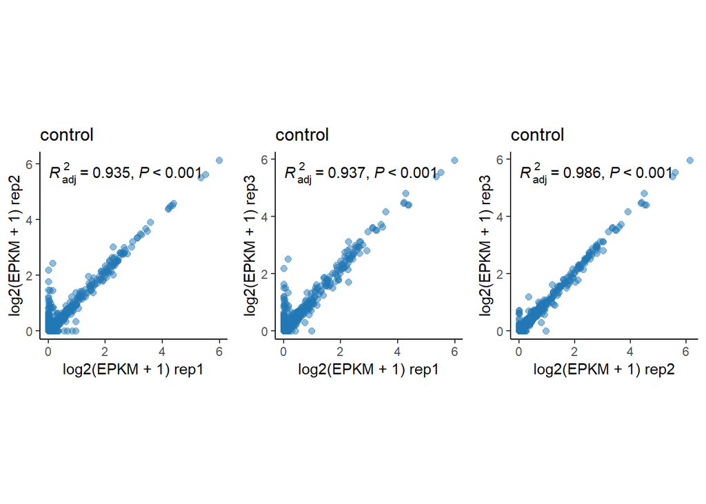

#### shRNA33

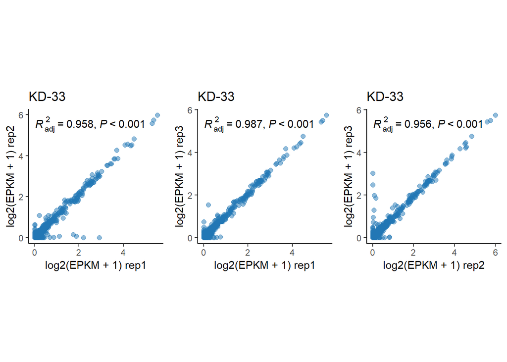

#### shRNA37

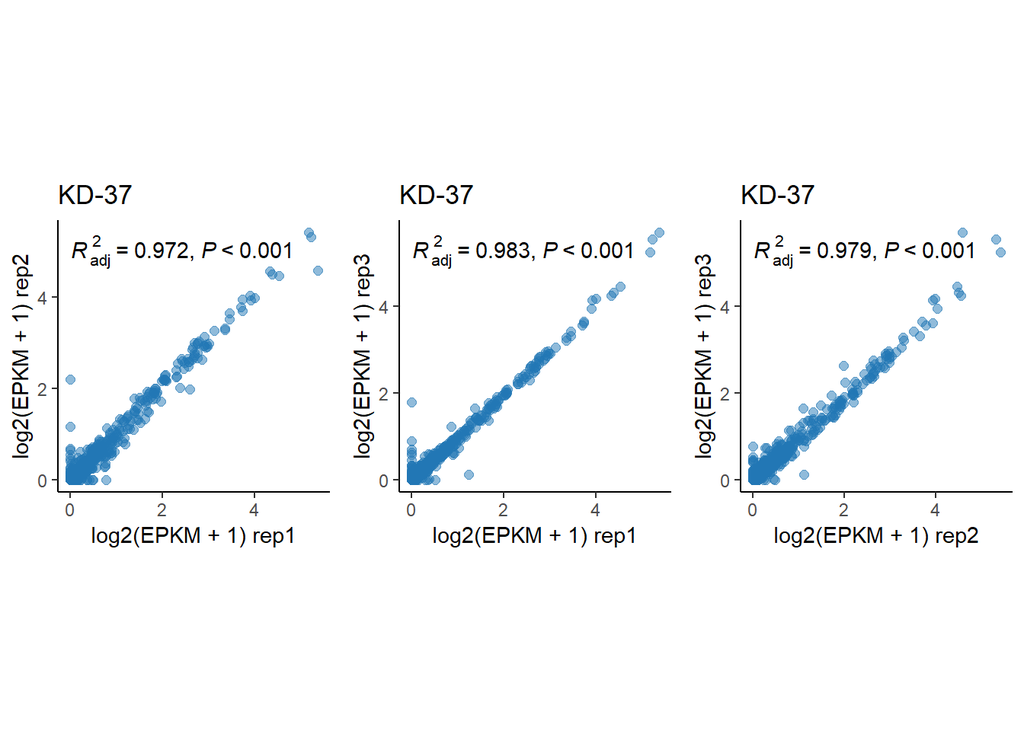

### Quartile_BoxPlot

for the quartile analysis with epkm –> we should use just epkm for scramble –> since the KD affects editing frequency + editing sites. quartile bins is defined based on the average value of 3 SCR samples from high to low.

#### SCR, shRNA33, shRNA37 cut by SCR EPKM value

```
## [1] "Each quartile genes number: 1625"
```

```
## # A tibble: 10 × 10
##      bin .y.   group1  group2     n1    n2 statistic         p     p.adj
##    <dbl> <chr> <chr>   <chr>   <int> <int>     <dbl>     <dbl>     <dbl>
##  1     1 EPKM  SCR     shRNA33  4875  4875 12681231  9.12e-  9 2.74e-  8
##  2     1 EPKM  SCR     shRNA37  4875  4875 12608667  1.75e-  7 5.25e-  7
##  3     2 EPKM  SCR     shRNA33  4875  4875 14507235  4.21e- 81 1.26e- 80
##  4     2 EPKM  SCR     shRNA37  4875  4875 13769748  1.44e- 42 4.32e- 42
##  5     2 EPKM  shRNA33 shRNA37  4875  4875 11166648  1.37e-  7 4.11e-  7
##  6     3 EPKM  SCR     shRNA37  4875  4875 12530367  4.54e-  7 1.36e-  6
##  7     3 EPKM  shRNA33 shRNA37  4875  4875 12618215  5.96e-  9 1.79e-  8
##  8     4 EPKM  SCR     shRNA33  4875  4875  8109562. 0         0
##  9     4 EPKM  SCR     shRNA37  4875  4875  4977375  0         0
## 10     4 EPKM  shRNA33 shRNA37  4875  4875  8731313  2.76e-136 8.28e-136
## # ℹ 1 more variable: p.adj.signif <chr>
```

```
## # A tibble: 12 × 4
##      bin sample_group mean_EPKM median_EPKM
##    <dbl> <chr>            <dbl>       <dbl>
##  1     1 SCR            0.492      0.0519
##  2     1 shRNA33        0.506      0.0465
##  3     1 shRNA37        0.477      0.0468
##  4     2 SCR            0.00652    0.00571
##  5     2 shRNA33        0.00623    0.00300
##  6     2 shRNA37        0.00681    0.00363
##  7     3 SCR            0.00101    0.000593
##  8     3 shRNA33        0.00335    0
##  9     3 shRNA37        0.00270    0
## 10     4 SCR            0          0
## 11     4 shRNA33        0.00358    0
## 12     4 shRNA37        0.00636    0.00123
```

#### SCR, shRNA cut by SCR EPKM value

```
## # A tibble: 3 × 10
##     bin .y.   group1 group2    n1    n2 statistic        p    p.adj p.adj.signif
##   <dbl> <chr> <chr>  <chr>  <int> <int>     <dbl>    <dbl>    <dbl> <chr>
## 1     1 EPKM  SCR    shRNA   4875  9750 25289898  2.39e-10 2.39e-10 ****
## 2     2 EPKM  SCR    shRNA   4875  9750 28276983  3   e-80 3   e-80 ****
## 3     4 EPKM  SCR    shRNA   4875  9750 13086938. 0        0        ****
```

```
## # A tibble: 8 × 4
##     bin combined_group mean_EPKM median_EPKM
##   <dbl> <chr>              <dbl>       <dbl>
## 1     1 SCR              0.492      0.0519
## 2     1 shRNA            0.491      0.0467
## 3     2 SCR              0.00652    0.00571
## 4     2 shRNA            0.00652    0.00331
## 5     3 SCR              0.00101    0.000593
## 6     3 shRNA            0.00302    0
## 7     4 SCR              0          0
## 8     4 shRNA            0.00497    0
```

## 0.2 EPKM-CDS+3’utr

### EPKM scatter plot

#### SCR

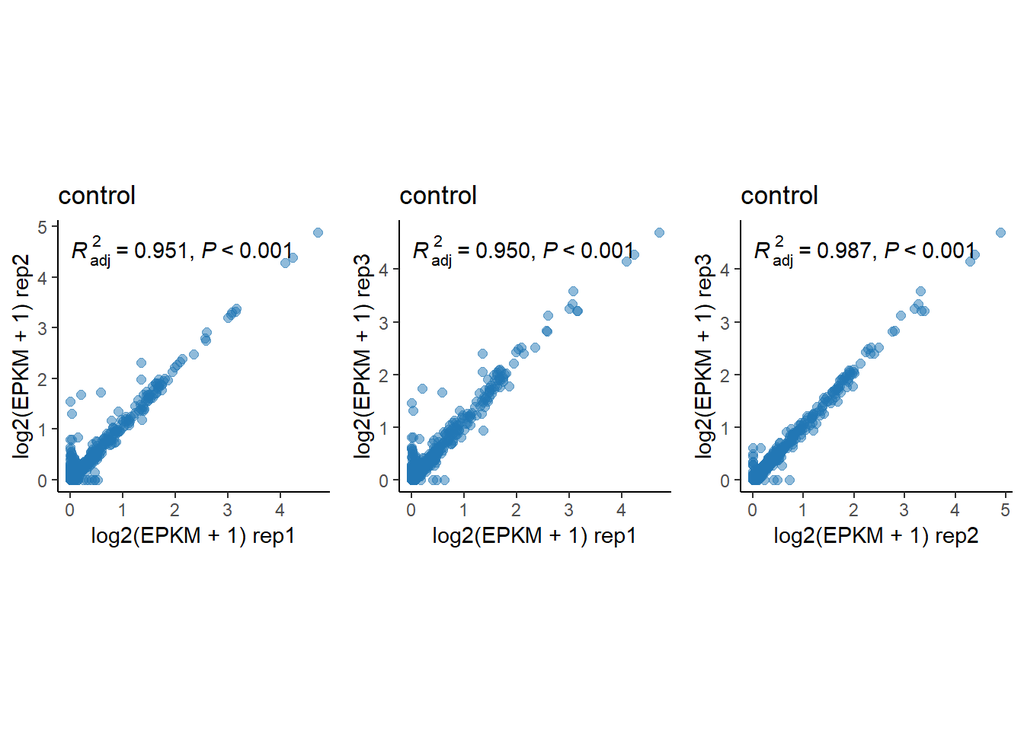

#### shRNA33

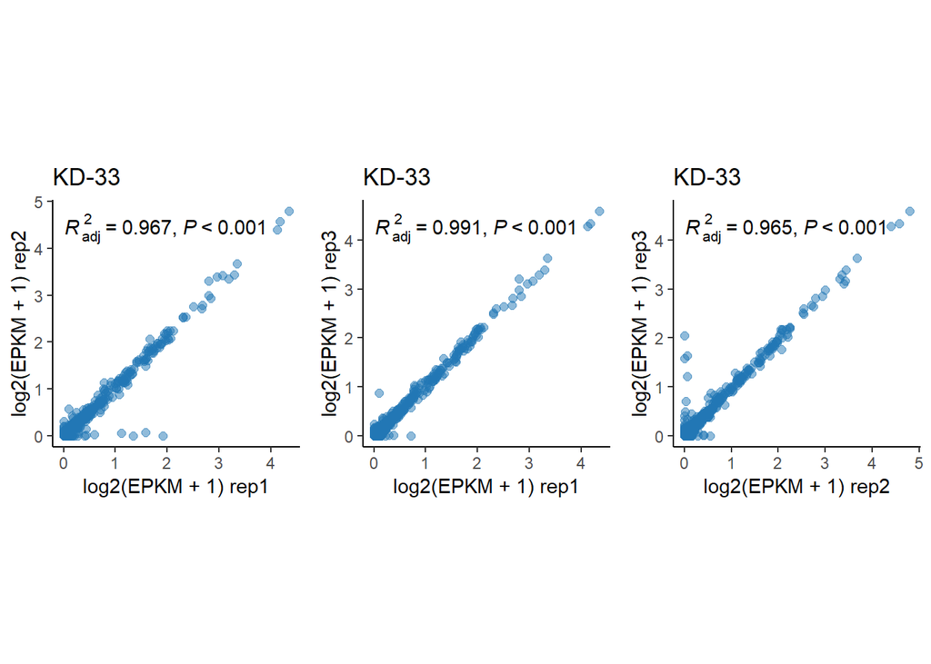

#### shRNA37

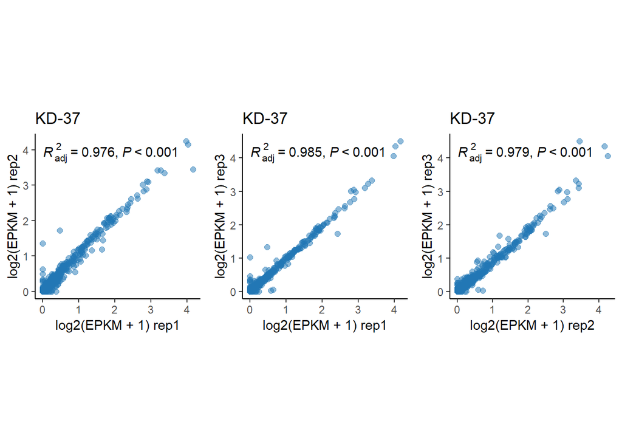

### Quartile_BoxPlot

for the quartile analysis with epkm –> we should use just epkm for scramble –> since the KD affects editing frequency + editing sites. quartile bins is defined based on the average value of 3 SCR samples from high to low.

#### SCR, shRNA33, shRNA37 cut by SCR EPKM value

```
## [1] "Each quartile genes number: 2011"
```

```
## # A tibble: 11 × 10
##      bin .y.   group1  group2     n1    n2 statistic         p     p.adj
##    <dbl> <chr> <chr>   <chr>   <int> <int>     <dbl>     <dbl>     <dbl>
##  1     1 EPKM  SCR     shRNA33  6033  6033 18892084. 2.89e-  4 8.67e-  4
##  2     1 EPKM  SCR     shRNA37  6033  6033 18910692. 1.97e-  4 5.91e-  4
##  3     2 EPKM  SCR     shRNA33  6033  6033 20977984  5.96e- 48 1.79e- 47
##  4     2 EPKM  SCR     shRNA37  6033  6033 20132914. 4.42e- 24 1.33e- 23
##  5     2 EPKM  shRNA33 shRNA37  6033  6033 17448131  8.26e-  5 2.48e-  4
##  6     3 EPKM  SCR     shRNA33  6033  6033 22246610  5.64e-104 1.69e-103
##  7     3 EPKM  SCR     shRNA37  6033  6033 20895310. 1.13e- 46 3.39e- 46
##  8     3 EPKM  shRNA33 shRNA37  6033  6033 17012995  5.78e- 11 1.73e- 10
##  9     4 EPKM  SCR     shRNA33  6033  6033 11785128. 0         0
## 10     4 EPKM  SCR     shRNA37  6033  6033  9169850. 0         0
## 11     4 EPKM  shRNA33 shRNA37  6033  6033 15570208. 1.85e- 49 5.55e- 49
## # ℹ 1 more variable: p.adj.signif <chr>
```

```
## # A tibble: 12 × 4
##      bin sample_group mean_EPKM median_EPKM
##    <dbl> <chr>            <dbl>       <dbl>
##  1     1 SCR          0.209        0.0288
##  2     1 shRNA33      0.226        0.0277
##  3     1 shRNA37      0.214        0.0279
##  4     2 SCR          0.00428      0.00375
##  5     2 shRNA33      0.00429      0.00286
##  6     2 shRNA37      0.00506      0.00301
##  7     3 SCR          0.000923     0.000812
##  8     3 shRNA33      0.00114      0
##  9     3 shRNA37      0.00139      0.000442
## 10     4 SCR          0.0000350    0
## 11     4 shRNA33      0.00161      0
## 12     4 shRNA37      0.00208      0.000355
```

#### SCR, shRNA cut by SCR EPKM value

```
## # A tibble: 4 × 10
##     bin .y.   group1 group2    n1    n2 statistic        p    p.adj p.adj.signif
##   <dbl> <chr> <chr>  <chr>  <int> <int>     <dbl>    <dbl>    <dbl> <chr>
## 1     1 EPKM  SCR    shRNA   6033 12066 37802777  2.21e- 5 2.21e- 5 ****
## 2     2 EPKM  SCR    shRNA   6033 12066 41110898. 4.36e-46 4.36e-46 ****
## 3     3 EPKM  SCR    shRNA   6033 12066 43141920. 1.56e-97 1.56e-97 ****
## 4     4 EPKM  SCR    shRNA   6033 12066 20954978  0        0        ****
```

```
## # A tibble: 8 × 4
##     bin combined_group mean_EPKM median_EPKM
##   <dbl> <chr>              <dbl>       <dbl>
## 1     1 SCR            0.209        0.0288
## 2     1 shRNA          0.220        0.0278
## 3     2 SCR            0.00428      0.00375
## 4     2 shRNA          0.00467      0.00292
## 5     3 SCR            0.000923     0.000812
## 6     3 shRNA          0.00126      0.000343
## 7     4 SCR            0.0000350    0
## 8     4 shRNA          0.00184      0
```

# 1. EPKM *10e3

per_million_mapped_read_counts = sum(sample_sites_counts$gene_expression_counts) / 1e6

## 2.1 EPKM-CDS -*10e3

### Quartile_BoxPlot

for the quartile analysis with epkm –> we should use just epkm for scramble –> since the KD affects editing frequency + editing sites. quartile bins is defined based on the average value of 3 SCR samples from high to low.

#### SCR, shRNA33, shRNA37 cut by SCR EPKM value

```
## [1] "Each quartile genes number: 1625"
```

```
## # A tibble: 10 × 10
##      bin .y.   group1  group2     n1    n2 statistic         p     p.adj
##    <dbl> <chr> <chr>   <chr>   <int> <int>     <dbl>     <dbl>     <dbl>
##  1     1 EPKM  SCR     shRNA33  4875  4875 12681231  9.12e-  9 2.74e-  8
##  2     1 EPKM  SCR     shRNA37  4875  4875 12608667  1.75e-  7 5.25e-  7
##  3     2 EPKM  SCR     shRNA33  4875  4875 14507235  4.21e- 81 1.26e- 80
##  4     2 EPKM  SCR     shRNA37  4875  4875 13769748  1.44e- 42 4.32e- 42
##  5     2 EPKM  shRNA33 shRNA37  4875  4875 11166648  1.37e-  7 4.11e-  7
##  6     3 EPKM  SCR     shRNA37  4875  4875 12530367  4.54e-  7 1.36e-  6
##  7     3 EPKM  shRNA33 shRNA37  4875  4875 12618215  5.96e-  9 1.79e-  8
##  8     4 EPKM  SCR     shRNA33  4875  4875  8109562. 0         0
##  9     4 EPKM  SCR     shRNA37  4875  4875  4977375  0         0
## 10     4 EPKM  shRNA33 shRNA37  4875  4875  8731313  2.76e-136 8.28e-136
## # ℹ 1 more variable: p.adj.signif <chr>
```

```
## # A tibble: 12 × 4
##      bin sample_group mean_EPKM median_EPKM
##    <dbl> <chr>            <dbl>       <dbl>
##  1     1 SCR             492.        51.9
##  2     1 shRNA33         506.        46.5
##  3     1 shRNA37         477.        46.8
##  4     2 SCR               6.52       5.71
##  5     2 shRNA33           6.23       3.00
##  6     2 shRNA37           6.81       3.63
##  7     3 SCR               1.01       0.593
##  8     3 shRNA33           3.35       0
##  9     3 shRNA37           2.70       0
## 10     4 SCR               0          0
## 11     4 shRNA33           3.58       0
## 12     4 shRNA37           6.36       1.23
```

#### SCR, shRNA cut by SCR EPKM value

```
## # A tibble: 3 × 10
##     bin .y.   group1 group2    n1    n2 statistic        p    p.adj p.adj.signif
##   <dbl> <chr> <chr>  <chr>  <int> <int>     <dbl>    <dbl>    <dbl> <chr>
## 1     1 EPKM  SCR    shRNA   4875  9750 25289898  2.39e-10 2.39e-10 ****
## 2     2 EPKM  SCR    shRNA   4875  9750 28276983  3   e-80 3   e-80 ****
## 3     4 EPKM  SCR    shRNA   4875  9750 13086938. 0        0        ****
```

```
## # A tibble: 8 × 4
##     bin combined_group mean_EPKM median_EPKM
##   <dbl> <chr>              <dbl>       <dbl>
## 1     1 SCR               492.        51.9
## 2     1 shRNA             491.        46.7
## 3     2 SCR                 6.52       5.71
## 4     2 shRNA               6.52       3.31
## 5     3 SCR                 1.01       0.593
## 6     3 shRNA               3.02       0
## 7     4 SCR                 0          0
## 8     4 shRNA               4.97       0
```

### Differential results

Using normalized gene expression values rather than raw counts. DESeq2 requires raw count data as input for its statistical model to perform differential expression analysis. Here, we can use other methods for differential expression analysis that can handle normalized gene expression data, such as limma-voom or edgeR.

```
## [1] 6479    9
```

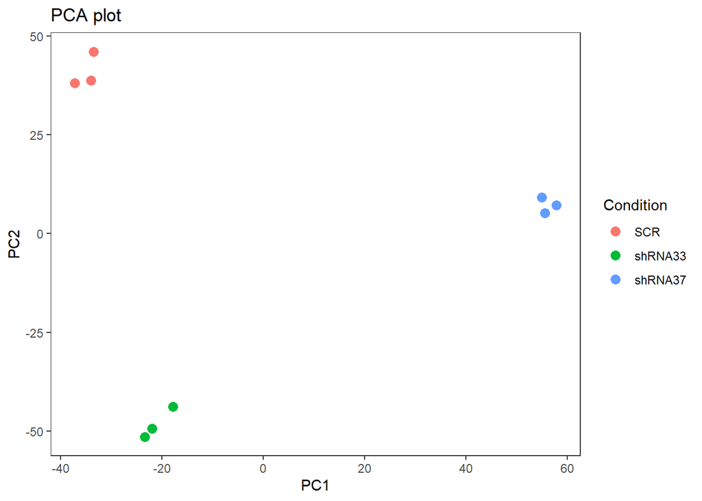

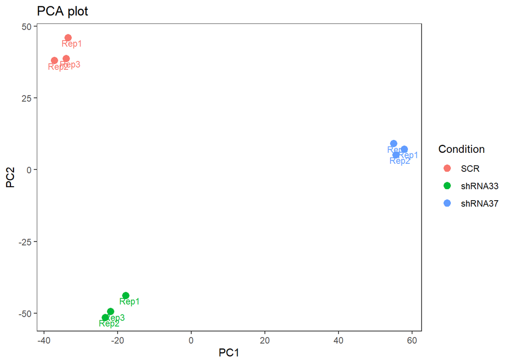

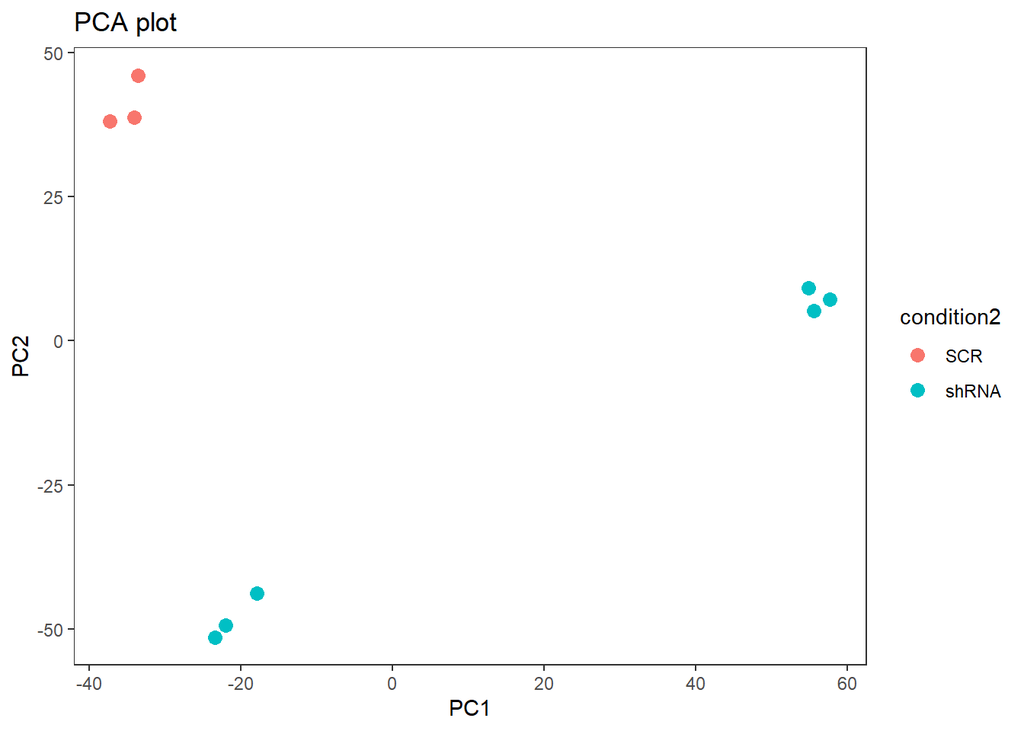

```
## # A tibble: 3 × 2
##   direction count
##   <chr>     <int>
## 1 down        245
## 2 ns         6000
## 3 up          255
```

```
## # A tibble: 3 × 2
##   direction count
##   <chr>     <int>
## 1 down        299
## 2 ns         5740
## 3 up          461
```

```
## # A tibble: 3 × 2
##   direction count
##   <chr>     <int>
## 1 down        253
## 2 ns         5771
## 3 up          476
```

```
## # A tibble: 3 × 2
##   direction count
##   <chr>     <int>
## 1 down        108
## 2 ns         6307
## 3 up           85
```

## 2.2 EPKM-CDS+3’utr-*10e3

### Quartile_BoxPlot

for the quartile analysis with epkm –> we should use just epkm for scramble –> since the KD affects editing frequency + editing sites. quartile bins is defined based on the average value of 3 SCR samples from high to low.

#### SCR, shRNA33, shRNA37 cut by SCR EPKM value

```
## [1] "Each quartile genes number: 2011"
```

```
## # A tibble: 11 × 10
##      bin .y.   group1  group2     n1    n2 statistic         p     p.adj
##    <dbl> <chr> <chr>   <chr>   <int> <int>     <dbl>     <dbl>     <dbl>
##  1     1 EPKM  SCR     shRNA33  6033  6033 18892084. 2.89e-  4 8.67e-  4
##  2     1 EPKM  SCR     shRNA37  6033  6033 18910692. 1.97e-  4 5.91e-  4
##  3     2 EPKM  SCR     shRNA33  6033  6033 20977984  5.96e- 48 1.79e- 47
##  4     2 EPKM  SCR     shRNA37  6033  6033 20132914. 4.42e- 24 1.33e- 23
##  5     2 EPKM  shRNA33 shRNA37  6033  6033 17448131  8.26e-  5 2.48e-  4
##  6     3 EPKM  SCR     shRNA33  6033  6033 22246610  5.64e-104 1.69e-103
##  7     3 EPKM  SCR     shRNA37  6033  6033 20895310. 1.13e- 46 3.39e- 46
##  8     3 EPKM  shRNA33 shRNA37  6033  6033 17012995  5.78e- 11 1.73e- 10
##  9     4 EPKM  SCR     shRNA33  6033  6033 11785128. 0         0
## 10     4 EPKM  SCR     shRNA37  6033  6033  9169850. 0         0
## 11     4 EPKM  shRNA33 shRNA37  6033  6033 15570208. 1.85e- 49 5.55e- 49
## # ℹ 1 more variable: p.adj.signif <chr>
```

```
## # A tibble: 12 × 4
##      bin sample_group mean_EPKM median_EPKM
##    <dbl> <chr>            <dbl>       <dbl>
##  1     1 SCR           209.          28.8
##  2     1 shRNA33       226.          27.7
##  3     1 shRNA37       214.          27.9
##  4     2 SCR             4.28         3.75
##  5     2 shRNA33         4.29         2.86
##  6     2 shRNA37         5.06         3.01
##  7     3 SCR             0.923        0.812
##  8     3 shRNA33         1.14         0
##  9     3 shRNA37         1.39         0.442
## 10     4 SCR             0.0350       0
## 11     4 shRNA33         1.61         0
## 12     4 shRNA37         2.08         0.355
```

#### SCR, shRNA cut by SCR EPKM value

```
## # A tibble: 4 × 10
##     bin .y.   group1 group2    n1    n2 statistic        p    p.adj p.adj.signif
##   <dbl> <chr> <chr>  <chr>  <int> <int>     <dbl>    <dbl>    <dbl> <chr>
## 1     1 EPKM  SCR    shRNA   6033 12066 37802777  2.21e- 5 2.21e- 5 ****
## 2     2 EPKM  SCR    shRNA   6033 12066 41110898. 4.36e-46 4.36e-46 ****
## 3     3 EPKM  SCR    shRNA   6033 12066 43141920. 1.56e-97 1.56e-97 ****
## 4     4 EPKM  SCR    shRNA   6033 12066 20954978  0        0        ****
```

```
## # A tibble: 8 × 4
##     bin combined_group mean_EPKM median_EPKM
##   <dbl> <chr>              <dbl>       <dbl>
## 1     1 SCR             209.          28.8
## 2     1 shRNA           220.          27.8
## 3     2 SCR               4.28         3.75
## 4     2 shRNA             4.67         2.92
## 5     3 SCR               0.923        0.812
## 6     3 shRNA             1.26         0.343
## 7     4 SCR               0.0350       0
## 8     4 shRNA             1.84         0
```

### Differential results

Using normalized gene expression values rather than raw counts. DESeq2 requires raw count data as input for its statistical model to perform differential expression analysis. Here, we can use other methods for differential expression analysis that can handle normalized gene expression data, such as limma-voom or edgeR.

```
## [1] 8016    9
```

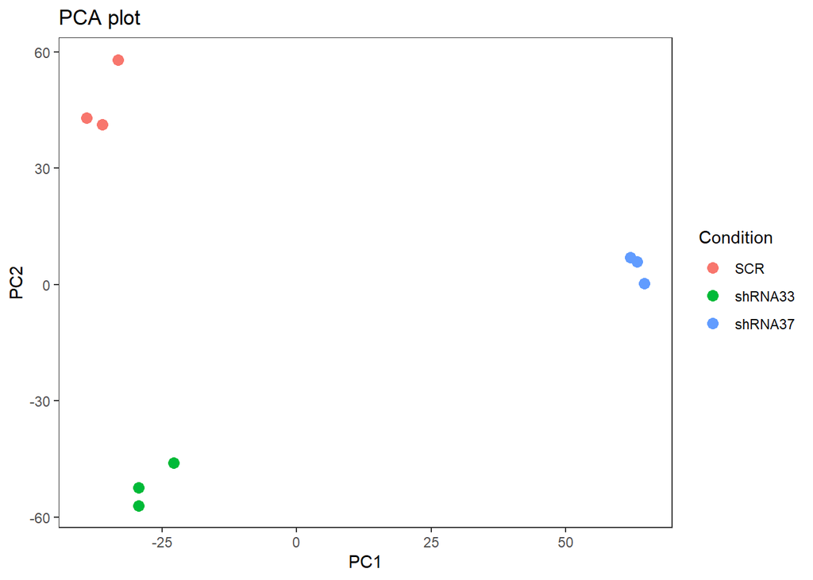

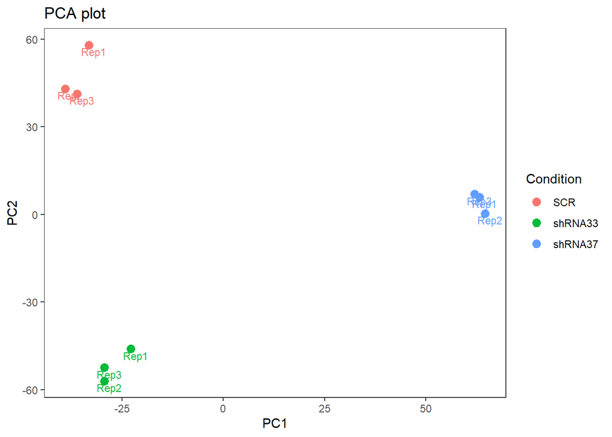

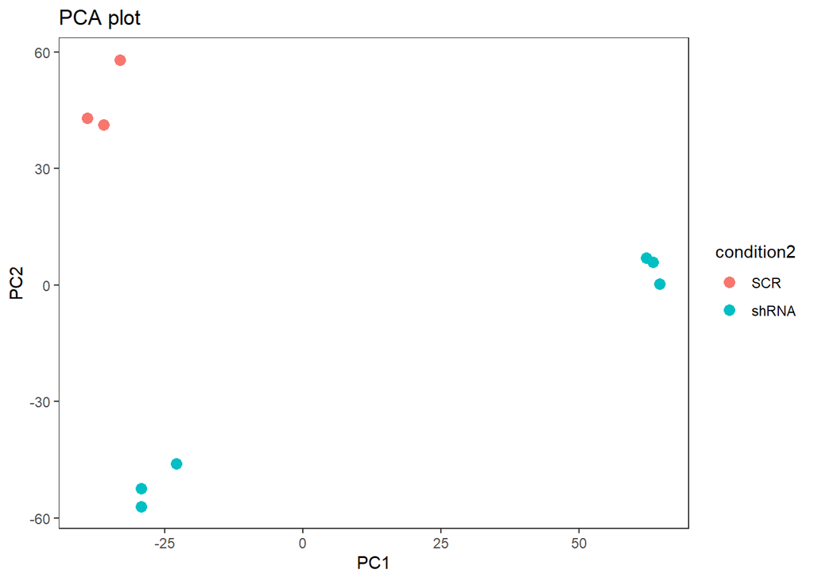

```
## # A tibble: 3 × 2
##   direction count
##   <chr>     <int>
## 1 down        408
## 2 ns         7410
## 3 up          226
```

```
## # A tibble: 3 × 2
##   direction count
##   <chr>     <int>
## 1 down        585
## 2 ns         6887
## 3 up          572
```

```
## # A tibble: 3 × 2
##   direction count
##   <chr>     <int>
## 1 down        418
## 2 ns         6886
## 3 up          740
```

```
## # A tibble: 3 × 2
##   direction count
##   <chr>     <int>
## 1 down        153
## 2 ns         7795
## 3 up           96
```